# Has Hawaii’s Public Health Measures Triumped over Covid? Forecasting Hawaii’s Covid Cases

## Forecasting: Prophet

Prophet is a R/Python package created by Facebook’s Core Data Science team to forecast time series.[^2] Further, Prophet works well with data that have strong seasonal effects and have periods of long historical data.

Prophet works best with daily data for at least one year.[^3] Because our data consists of daily records for the past 3 years, Prophet is an excellent model to work with.

```r
#install.packages('prophet') #installed on 11/25/22
library(prophet)
```

We will take the data_HI object and filter it into two objects with just the ds and y variables.

```r
#filter data_HI dataset
data_HI_pos_prophet<- data_HI %>%
  filter(overall_outcome == 'Positive') %>%
  dplyr::select(-c(1,3))

#changle variable names
colnames(data_HI_pos_prophet) <-c('ds','y')

#check if filter worked and str
head(data_HI_pos_prophet, 5)
```

|  | ds | y |
| --- | --- | --- |
| 1 | 2020-03-13 | 1 |
| 2 | 2020-03-14 | 3 |
| 3 | 2020-03-15 | 6 |
| 4 | 2020-03-16 | 6 |
| 5 | 2020-03-17 | 10 |

```r
str(data_HI_pos_prophet)
```

```
'data.frame':   983 obs. of  2 variables:
 $ ds: Date, format: "2020-03-13" "2020-03-14" ...
 $ y : int  1 3 6 6 10 20 31 48 56 70 ...
```

```r
#use the prophet function and set the frequency to daily
prophet1 <-prophet(data_HI_pos_prophet, daily.seasonality = TRUE)

#make a dataframe that would hold 3-years worth of predicted values
future1 <- make_future_dataframe(prophet1, periods = 1095)

#use predict function using the phrophet1 model to predict future1 values
#store this into an object
forecast1 <- predict(prophet1, future1)
```

Now, let’s plot.

```r
#plot forecast
dyplot.prophet(prophet1, forecast1)
```

[interactive chart not shown]

From a high-level overview of the data we again see that the number of positive cases is trending upward with a 3-year forecast.

A great feature of prophet is the cursor button allowing us to zoom in on certain parts of the data by moving the left and right bars horizontally. An interesting insight is that from the middle of Dec 2022 there is a sharp increase in the slope. It is projected there will be a high number of positve cases. However, as we move toward future values the SD gets bigger. What this means for public officials is to prepare for the upcoming positive cases in Hawaii.

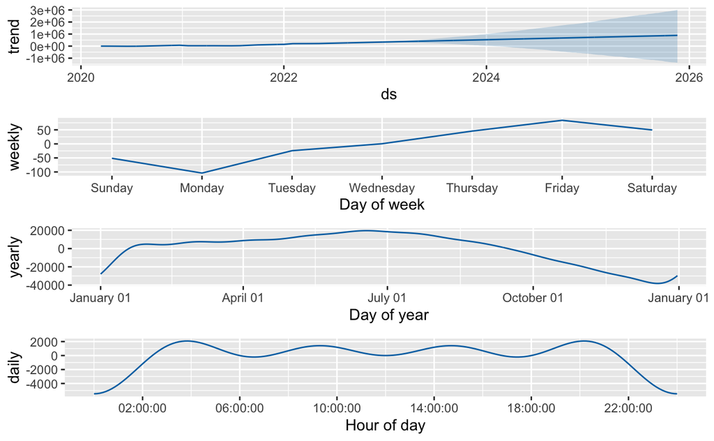

```r
prophet_plot_components(prophet1, forecast1)
```

### Limitations

One limitation from this project is that we know because the data of positive and negative cases are accumulation of values, the forecast will naturally trend upward with its positive slope. Therefore, the slope would not be negative. Thus, this would not directly indicate if the Covid pandemic is improving in Hawaii.

Also, based on this dataset have learned that unlike Polio where it is almost eradicated with the exception to developing, third-world countries, we cannot conclude that with Covid regrading this dataset. Thus, dataset does not help us determine if Covid is a disease that is capable of being eradicated or if it will be a disesase with seasonal trends like influenza.

### Appendix

It is also good practice to create ACF and PACF plots.

ACF is a complete auto-correlation function (aka correlogram) which gives values of autocorrelation of any series and its various lagged values. To elucidate, ACF measures the correlation between ysubt and ysubt-1, ysubt-3, etc.). Because time series can have components like trends, seasonality, cyclic and residual, ACF considers all of this and finding correlations.

PCF is partial auto-correlation function, it finds correlations of the residuals with the next lag value. To elucidate, there is another factor (like ysubt-1) that indirectly affects the correlation of ysubt and ysubt-2. What PCF does is remove in-between correlations like ysubt-1 and measures the direct correlation btween ysubt and ysubt-2.

##### Plot Theory

The correlation coefficients between lagged values can be plotted with ACF and PACF. Below the the horizontal dash line (blue) represents the significance threshold and only spikes that are above this dash line are considered significant. The spikes can be significant positive and negative. The spikes that are in-between the significance boundaries are not distinguishable from zero.

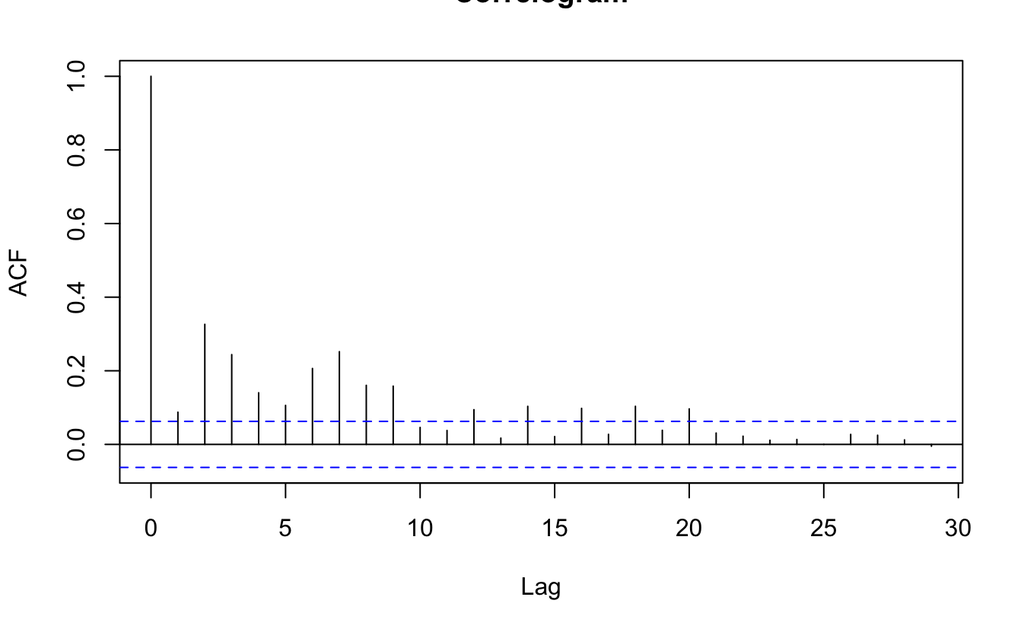

```r
#ACF Plot
#residuals is the difference between acutal and fitted values
acf(arima_model_pos$residuals, main = 'Correlogram')
```

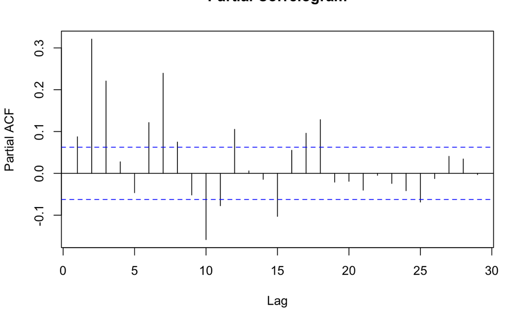

```r
#PACF Plot
pacf(arima_model_pos$residuals, main ='Partial Correlogram')
```

There quite a few significant spikes at the 1st, 2nd, and 3rd spike.

[^1]: https://healthdata.gov/dataset/COVID-19-Diagnostic-Laboratory-Testing-PCR-Testing/j8mb-icvb
[^2]: https://facebook.github.io/prophet/#:~:text=Prophet%20is%20a%20forecasting%20procedure,Install%20Prophet
[^3]: https://mode.com/example-gallery/forecasting_prophet_r_cookbook/